# Design of Data Experiments - Exercises

# Exercise 2.1: Determinants of academic performance

1.) An example of a study that examines the impact of exercising on academic performance using cross-sectional data would be to look at different individuals with different levels of exercising and their academic performance.

2.) An example of a study that examines the impact of exercising on academic performance using time-series data would be to look at one specific individual over time and relate his or her exercise level to his or her level of performance.

3.) An example of a study that examines the impact of exercising on academic performance using panel data would be to look at different individuals over time and relate their exercise level to their level of performance.

The first example only uses variation across individuals, the second example uses only variation within an individual over time, and the third example uses variation both over individuals and over time.

4.) We first read in the data:

```r
df_math <- read_csv("../Data/Out_Data/lecture2_math.csv")
```

We then take the grouped average of the number of countries visited in the last twelve months. For this, we can use the command *group_by* from the *dplyr* package and the pipe operator (%>%) from the *magrittr* package that allows us to perform a sequence of commands. The results suggest that women were traveling to more countries than men did.

```r
df_math %>%
  group_by(gender) %>%
  summarize(countries_mean=mean(countries))
```

```
## # A tibble: 2 × 2
##   gender countries_mean
##   <chr>           <dbl>
## 1 female           4.29
## 2 male             3.59
```

We can also illustrate this visually with a scatter plot:

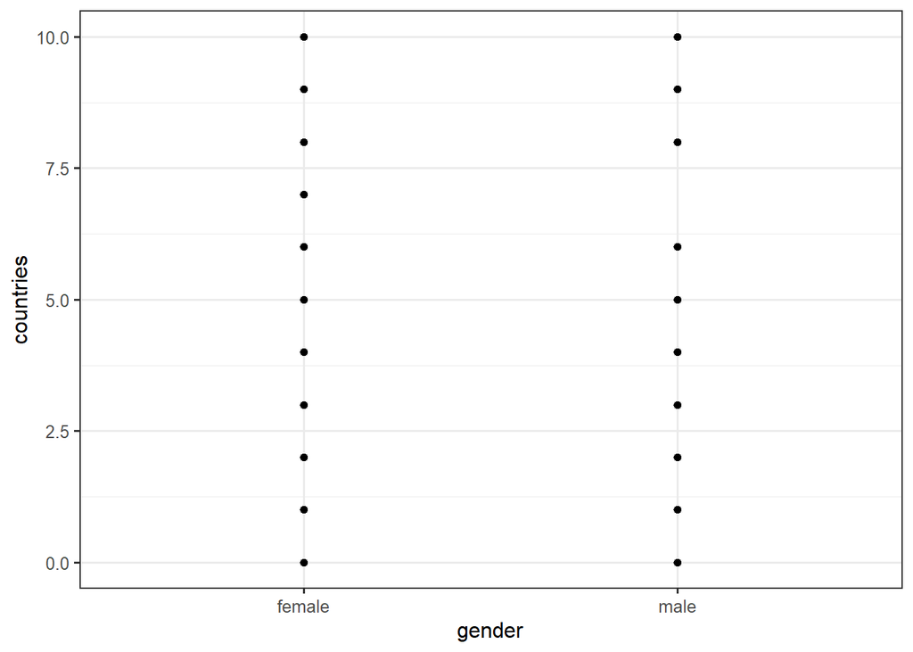

```r
ggplot(data=df_math,aes(x=gender,y=countries)) +
  geom_point() +
  theme_bw(base_size=12)
```

5.) The drawback of the scatter plot when using discrete variables on both the x-axis and on the y-axis (gender and number of countries) is that we do not see the number of observations behind one data point. For example, there are three women who visited 9 countries but we only see a single point in the scatter plot. An alternative is jittering the data that takes the points apart. With the arguments height=0 and width=0.2, we move the dots a little bit on the x-axis (width=0.2) but not on the y-axis (height=0) because the latter could distort our impression of the relationship between *gender* and *countries*.

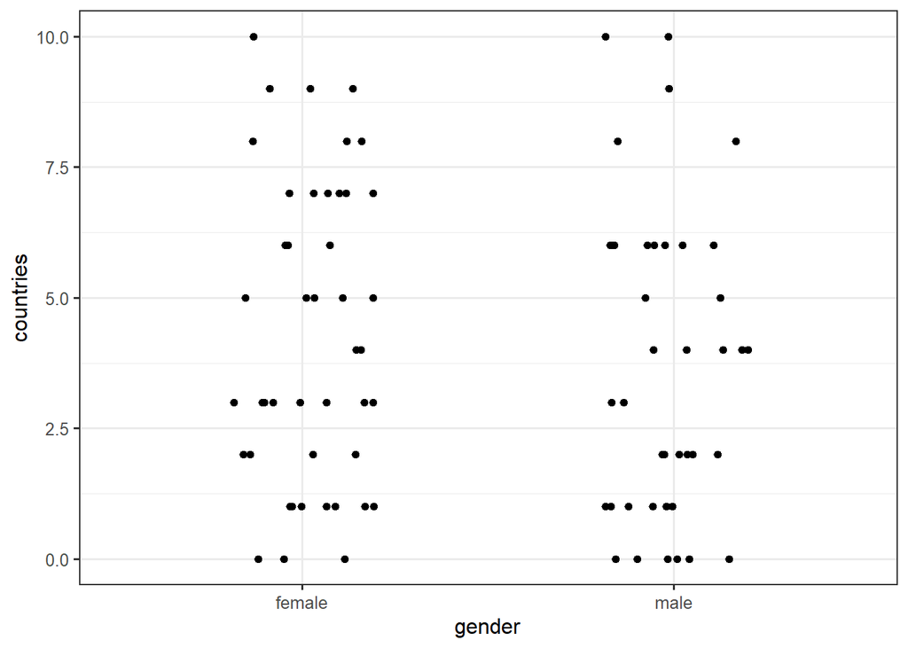

```r
set.seed(1234)
ggplot(data=df_math,aes(x=gender,y=countries)) +
  geom_jitter(width = 0.2, height=0) +
  theme_bw(base_size=12)
```

6.) When looking at the average gym visits per gender, we observe that women go more often to the gym:

```r
df_math %>%
  group_by(gender) %>%
  summarize(gym_visits_mean=mean(gym_visits))
```

```
## # A tibble: 2 × 2
##   gender gym_visits_mean
##   <chr>            <dbl>
## 1 female            9.76
## 2 male              6.44
```

A scatter plot with jittering can be used to visually illustrate this empirical relationship:

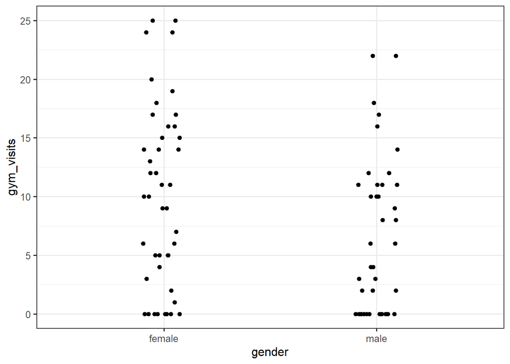

```r
ggplot(data=df_math,aes(x=gender,y=gym_visits)) +
  geom_jitter(width=0.1,height=0) +
  theme_bw(base_size=12)
```

7.) When looking at the relationship between traveling (number of countries visited) and math points, there seems to be no obvious relationship.

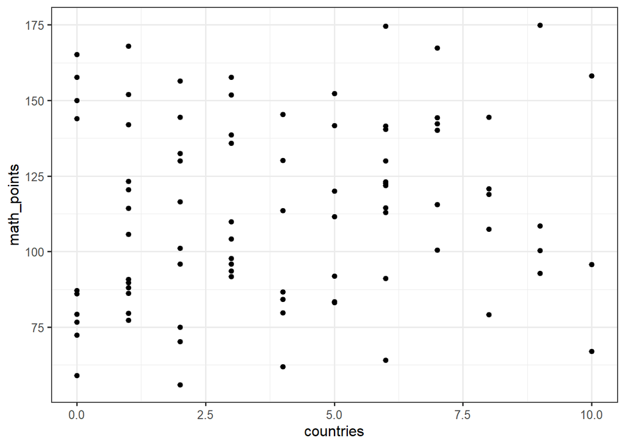

```r
ggplot(data=df_math,aes(x=countries,y=math_points)) +
  geom_point() +
  theme_bw(base_size=12)
```

8.) Exercising seems to be clearly positively related to academic performance:

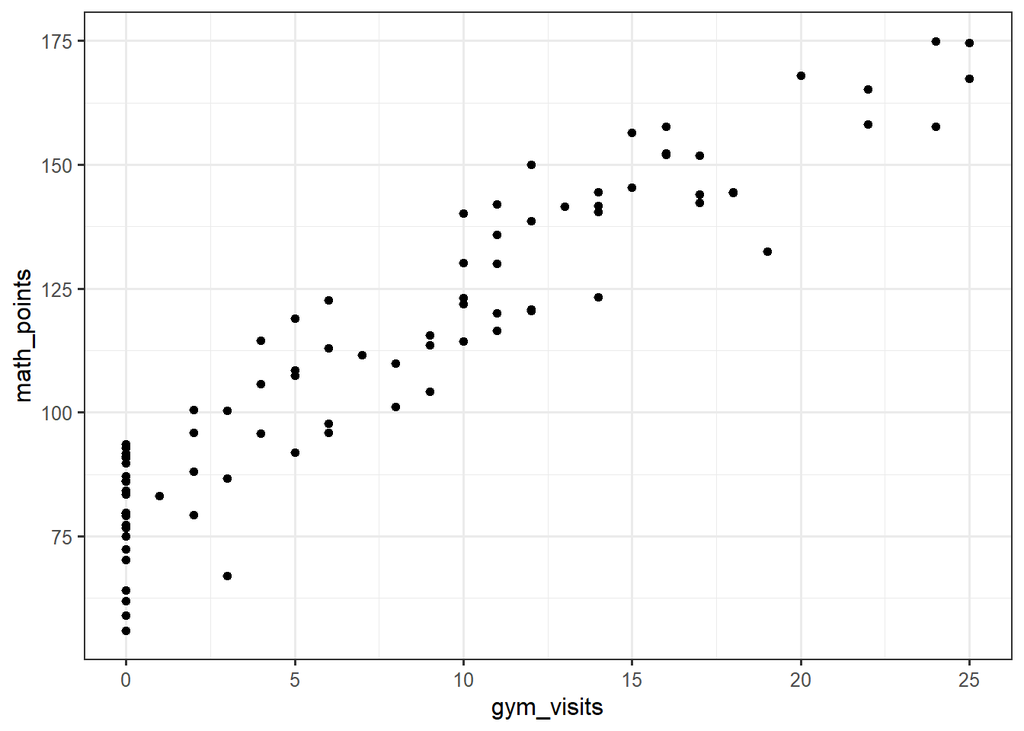

```r
ggplot(data=df_math,aes(x=gym_visits,y=math_points)) +
  geom_point() +
  theme_bw(base_size=12)
```

# Exercise 2.2: GDP and life expectancy

We read in the data:

```r
df_gdp_life_expectancy <- read_csv("../Data/Out_Data/lecture2_gdp_life_expectancy.csv")
```

1.) We can look this up in the panel “Environment” and observe that there are 192 observations and eight variables in the dataset.

2.) When reading in the data using *read_csv*, we already see that there are four character variables (chr) and four numerical variables (dbl=double precision). The character variables are: *country*, *iso3c*, *region*, and *capital.* All of those character variables are regular categorical because we cannot order them. The numerical variables are: *longitude*, *latitude*, *gdppc*, and *life_expectancy*. All of the numerical variables are continuous because they can take on any value within a certain interval. We can also use the *glimpse* function (*dplyr*) to get a sense of the number of observations, the number of variables, and the variable types:

```r
df_gdp_life_expectancy %>%
  glimpse()
```

```
## Rows: 192
## Columns: 8
## $ country         <chr> "Afghanistan", "Albania", "Algeria", "Andorra", "Angola", "Antigua and Barbuda", "Argentina", "Armenia", "Aruba", "Australia", "…
## $ iso3c           <chr> "AFG", "ALB", "DZA", "AND", "AGO", "ATG", "ARG", "ARM", "ABW", "AUS", "AUT", "AZE", "BHS", "BHR", "BGD", "BRB", "BLR", "BEL", "B…
## $ region          <chr> "South Asia", "Europe & Central Asia", "Middle East & North Africa", "Europe & Central Asia", "Sub-Saharan Africa", "Latin Ameri…
## $ capital         <chr> "Kabul", "Tirane", "Algiers", "Andorra la Vella", "Luanda", "Saint John's", "Buenos Aires", "Yerevan", "Oranjestad", "Canberra",…
## $ longitude       <dbl> 69.17610, 19.81720, 3.05097, 1.52180, 13.24200, -61.84560, -58.41730, 44.50900, -70.01670, 149.12900, 16.37980, 49.89320, -77.33…
## $ latitude        <dbl> 34.52280, 41.33170, 36.73970, 42.50750, -8.81155, 17.11750, -34.61180, 40.15960, 12.51670, -35.28200, 48.22010, 40.38340, 25.066…
## $ gdppc           <dbl> 0.4137579, 8.5751713, 5.3640280, 46.8124484, 2.3095341, 21.4945474, 14.1874827, 8.1252740, 33.9847906, 64.8359200, 56.0335738, 7…
## $ life_expectancy <dbl> 66.03500, 79.60200, 76.26100, 84.04100, 64.61700, 77.59800, 77.39500, 77.46585, 76.35300, 83.05122, 81.54146, 74.42900, 74.55200…
```

3.) We can again use the command *group_by* to calculate the means as well as the number of observations by region. There are striking differences in GDP per capita with 2650 and 3550 dollars in Sub-Saharan Africa and South Asia compared to 89700 dollars in North America. The variation in life expectancy is a lot lower but still lowest in Sub-Saharan Africa and highest in North America

```r
df_gdp_life_expectancy %>%
  group_by(region) %>%
  summarize(gdppc_mean=mean(gdppc),
            life_expectancy_mean=mean(life_expectancy),
            no_countries=n())
```

```
## # A tibble: 7 × 4
##   region                     gdppc_mean life_expectancy_mean no_countries
##   <chr>                           <dbl>                <dbl>        <int>
## 1 East Asia & Pacific             18.2                  73.6           31
## 2 Europe & Central Asia           34.8                  78.6           52
## 3 Latin America & Caribbean       17.3                  75.0           34
## 4 Middle East & North Africa      19.5                  76.7           20
## 5 North America                   89.7                  80.8            3
## 6 South Asia                       3.55                 72.8            8
## 7 Sub-Saharan Africa               2.65                 64.7           44
```

4.) We can implement this in two ways. The first way is to save the collapsed data by region in a dataframe (*gdp_coll*) and then use this as an argument in *ggplot*.

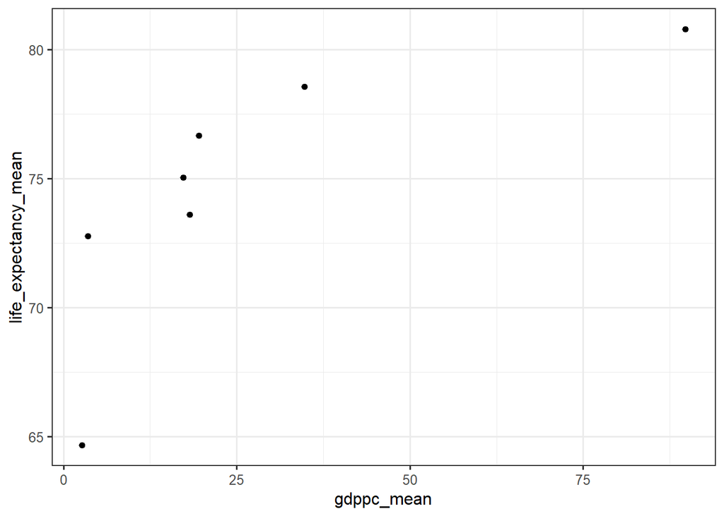

```r
gdp_coll <- df_gdp_life_expectancy %>%
  group_by(region) %>%
  summarize(gdppc_mean=mean(gdppc),
            life_expectancy_mean=mean(life_expectancy),
            no_countries=n())

ggplot(data=gdp_coll,aes(x=gdppc_mean,y=life_expectancy_mean)) +
  geom_point() +
  theme_bw(base_size=12)
```

The second way is to directly use *ggplot* as a part of the pipe of commands. This has the advantage that no object has to be saved and therefore fewer resources are used.

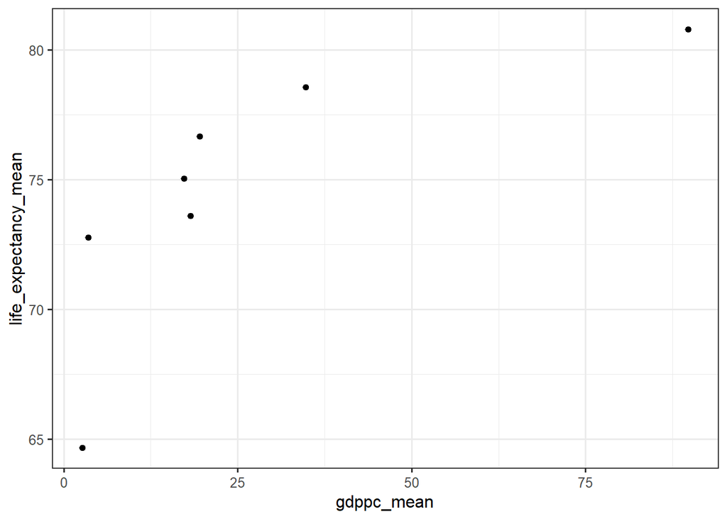

```r
df_gdp_life_expectancy %>%
  group_by(region) %>%
  summarize(gdppc_mean=mean(gdppc),
            life_expectancy_mean=mean(life_expectancy),
            no_countries=n()) %>%
  ggplot(aes(x=gdppc_mean,y=life_expectancy_mean)) +
  geom_point() +
  theme_bw(base_size=12)
```

5.) The results suggest that the pattern is very similar to the pattern at the country level. It is also non-linear with decreasing returns to a higher GDP per capita for higher levels of GDP per capita.

# Exercise 3.1: Sampling strategies

Sampling strategy (a) is a simple random sample and should not be biased.

Sampling strategy (b) is an example of anecdotal evidence and a non-representative sample because her friends might be different than the entire student population. The bias is such that the network is closer to the statistics students’ network than to the overall network among students.

Sampling strategy (c) is also a non-representative sample since students on Facebook who also participate in the survey are likely not representative for the overall population of students. The bias is probably that we overestimate the network of students since students on Facebook are more likely to have a denser network than other students.

Sampling strategy (d) is an example of a multistage design and should lead to unbiased estimates if there are enough clusters such that the randomization of clusters leads to a representative sample of students.

# Exercise 3.2: Survey on referendum preferences

We read in the data:

```r
df <- read_csv("../Data/Out_Data/lecture3_survey.csv")
```

1.) The mean support in the entire population can be calculated using the function *mean*. It is 59.8%.

```r
mean(df$support)
```

```
## [1] 0.5984
```

2.) The random sample can be generated using the command *simple_ra* from the *randomizr* package. Every individual in the population has a chance of 1000/N=0.01 to be in the sample where N is the number of individuals in the sample. We can get the number of individuals by first finding out the dimensions of the dataframe using the *dim* function (100,000 rows and 7 columns) and then taking the first element of 100,000 and 7.

We end up with 997 individuals. This small difference to 1000 is because we used a simple randomization and not a complete randomization (see lecture 11 for details).

```r
set.seed(1234)
N <- dim(df)[1]
df$sample <- simple_ra(N = N, prob=0.01)
df %>% tabyl(sample)
```

```
##  sample     n percent
##       0 99003 0.99003
##       1   997 0.00997
```

```r
mean(df$support[df$sample==1])
```

```
## [1] 0.5917753
```

3.) We first filter out car users in the population using the *filter* command from the *dplyr* package. We then take a simple random sample and calculate the mean support for car users which is substantially lower than in the full population.

```r
df_car <- df %>%
  filter(car=="Yes")

set.seed(1234)

df_car <- df_car %>%
  mutate(sample=simple_ra(N = dim(df_car)[1], prob=0.01 ))

mean(df_car$support[df_car$sample==1])
```

```
## [1] 0.4601227
```

4.) We first take a random sample of municipalities using the base R command *sample*. The function *unique* gives us a vector of all 2000 municipality ids in the data. We take the sample from this set of unique municipalities. Then we take the mean among this cluster which is very close to the overall mean in the population.

```r
set.seed(1234)
sampled_clusters <- sample(unique(df$municipality), size = 20)

df_cluster <- df %>%
  filter(municipality %in% sampled_clusters)

mean(df_cluster$support)
```

```
## [1] 0.6164773
```

5.) We first take random samples in each dataset, those with a car and those without a car and then combine the two subsamples using the *bind_rows* command.

```r
set.seed(1234)

df_nocar <- df %>%
  filter(car=="No") %>%
  mutate(sample=simple_ra(N = 50018, prob=0.01 ))

df_car <- df %>%
  filter(car=="Yes") %>%
  mutate(sample=simple_ra(N = 49982, prob=0.01 ))

df_stratified <- df_car %>%
  bind_rows(df_nocar) %>%
  filter(sample==1)
```

# Exercise 4.1: Threats to internal validity

1.) An obvious confounding factor is the severity of the fire. Larger or more intense fires naturally require the deployment of more firefighters.

2.) This is an example of reverse causation in which GDP growth also has an impact on the unemployment rate.

3.) A confounder could be the desire to lose weight. People who want to lose weight are more likely to exercise but at the same time are also more likely to do other things to decrease their weight, such as eating healthy food, getting enough sleep, etc.

4.) A confounding factor is the mother’s age, which affects the likelihood of a child being born with Down syndrome. Such a child is also more likely to be younger than their siblings.

5.) In this example, the John Henry effect could be at play, where students who narrowly miss out on a scholarship put in extra effort to catch up with those who received it.

# Exercise 4.2: Threats to internal validity

1.) Obvious confounders are motivation, ability, and the educational background of parents.

```r
df_schooling <- read_csv("../Data/Out_Data/lecture4_schooling_earnings.csv")
```

2.) If we plot the data, there is an obvious relationship between the two variables which also seems to be linear.

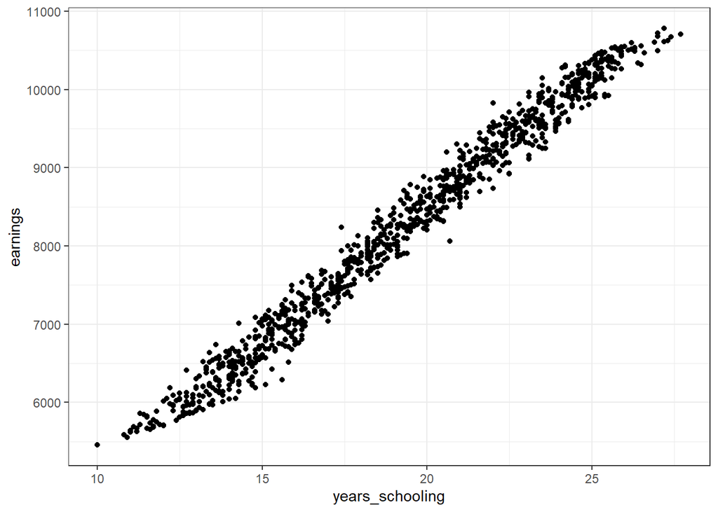

```r
ggplot(aes(x=years_schooling,y=earnings),data=df_schooling) +
  geom_point() +
  theme_bw()
```

3.) The average earnings of those with 15 years of schooling is about 6,500 Swiss Francs, while the average earnings of those with 25 years of schooling is about 10,000 Swiss Francs. Therefore, the difference in the y dimension is about 3,500 Swiss Francs and the difference in the x dimension is 10 years. Therefore, we expect a slope of about 3,500/10=350 Swiss Francs.

4.) We can use the *lm* command to estimate a linear regression model:

```r
summary(lm(earnings~years_schooling,data=df_schooling))
```

```
##
## Call:
## lm(formula = earnings ~ years_schooling, data = df_schooling)
##
## Residuals:
##     Min      1Q  Median      3Q     Max
## -704.95 -136.15    0.57  138.18  665.73
##
## Coefficients:
##                 Estimate Std. Error t value            Pr(>|t|)
## (Intercept)     1706.308     29.820   57.22 <0.0000000000000002 ***
## years_schooling  338.957      1.518  223.29 <0.0000000000000002 ***
## ---
## Signif. codes:  0 '***' 0.001 '**' 0.01 '*' 0.05 '.' 0.1 ' ' 1
##
## Residual standard error: 198.7 on 1021 degrees of freedom
## Multiple R-squared:  0.9799, Adjusted R-squared:  0.9799
## F-statistic: 4.986e+04 on 1 and 1021 DF,  p-value: < 0.00000000000000022
```

The estimated slope is about 339 Swiss Francs and thus very close to the 350 Swiss Francs that we expected.

5.) We use again the *lm* command and add motivation as a covariate:

```r
summary(lm(earnings~years_schooling+motivation,data=df_schooling))
```

```
##
## Call:
## lm(formula = earnings ~ years_schooling + motivation, data = df_schooling)
##
## Residuals:
##     Min      1Q  Median      3Q     Max
## -3.0244 -0.6509  0.0178  0.6559  3.2183
##
## Coefficients:
##                   Estimate Std. Error t value            Pr(>|t|)
## (Intercept)     1500.10919    0.15297    9806 <0.0000000000000002 ***
## years_schooling  149.98408    0.03061    4899 <0.0000000000000002 ***
## motivation       200.00844    0.03138    6373 <0.0000000000000002 ***
## ---
## Signif. codes:  0 '***' 0.001 '**' 0.01 '*' 0.05 '.' 0.1 ' ' 1
##
## Residual standard error: 0.9965 on 1020 degrees of freedom
## Multiple R-squared:      1,  Adjusted R-squared:      1
## F-statistic: 1.012e+09 on 2 and 1020 DF,  p-value: < 0.00000000000000022
```

The estimated impact of years of schooling decreases to about 150 Swiss Francs and the motivation coefficient is 200. This means that the previous estimate in part (4) not only captured the impact of years of schooling but also of motivation which is positively related to years of schooling. Therefore, the estimate in (4) suffered from an upward bias.

# Exercise 5.1: Five scientific studies

Study 1 mentions that it studies tax reforms that varied quasi-randomly. This means that they use observational and not experimental data where a natural experiment took place but not a proper experiment. In their paper, some cantons change wealth taxes, while others did not and this is the type of variation the authors use.

Study 2 does a randomized educational intervention with children aged 6 to 7 years. Therefore, this is a field experiment.

Study 3 randomizes the monetary payment for vaccinations in a randomized way which speaks for a field experiment.

Study 4 is also an experiment because the authors describe that they experimentally vary the altruistic punishment of defectors. This could be either a field experiment or a laboratory experiment but because very little additional information about the treated subjects is provided, it is probably a laboratory experiment.

Study 5 is not an experiment as the authors do not mention an experiment in the abstract. They use observational data.

# Exercise 5.2: The effectiveness of parachutes

The reasoning here is that very few individuals survive jumping from high altitude without parachutes but most individuals who jump with parachutes do survive. This empirical pattern holds independent of the characteristics of the jumpers (income, intelligence, body size) and thus it is likely to be a causal effect.

# Exercise 5.3: Experimental design I

One could conduct an experiment in which some employees get free coffee and free lunch sandwiches and others do not. The problem is if treated and non-treated individuals talk about it, spillovers are possible. A possible solution would be to allocate the treatment at the regional level, where employees have little interaction with each other.

# Exercise 5.4: Experimental design II

You could do this using A/B testing where participants are randomly shown different designs. The evaluation could be done via subscription data or via an evaluation form.

# Exercise 6.1: Causal estimands

1.) The Stable Unit Treatment Value Assumption (SUTVA) means that the potential outcomes of an individual only depend on their own treatment status, not on the treatment status of others.

2.) The ICEs look as follows:

```r
knitr::kable(df_exercising %>% dplyr::select(ID,D,Y,Y0,Y1,ICE))
```

| ID | D | Y | Y0 | Y1 | ICE |
| --- | --- | --- | --- | --- | --- |
| 1 | 1 | 82 | 80 | 82 | 2 |
| 2 | 0 | 95 | 95 | 99 | 4 |
| 3 | 0 | 125 | 125 | 135 | 10 |
| 4 | 0 | 140 | 140 | 154 | 14 |
| 5 | 0 | 140 | 140 | 138 | -2 |
| 6 | 1 | 131 | 125 | 131 | 6 |
| 7 | 0 | 95 | 95 | 107 | 12 |
| 8 | 1 | 144 | 145 | 144 | -1 |
| 9 | 0 | 135 | 135 | 139 | 4 |
| 10 | 0 | 135 | 135 | 138 | 3 |
| 11 | 1 | 94 | 95 | 94 | -1 |
| 12 | 0 | 145 | 145 | 146 | 1 |
| 13 | 1 | 151 | 150 | 151 | 1 |
| 14 | 0 | 95 | 95 | 97 | 2 |
| 15 | 1 | 135 | 130 | 135 | 5 |
| 16 | 1 | 113 | 100 | 113 | 13 |
| 17 | 1 | 138 | 125 | 138 | 13 |
| 18 | 1 | 135 | 120 | 135 | 15 |
| 19 | 0 | 90 | 90 | 104 | 14 |
| 20 | 1 | 125 | 125 | 125 | 0 |

3.) The average treatment effect (ATE) is the average of the ICEs ($\tau_i$s):
$$\tau = E[\tau_i] = \frac{1}{N} \sum^N_{i =
1}[Y_i(1) - Y_i(0)]$$
We can calculate that the sum of the ICEs is equal to 115, therefore $\tau =E[\tau_i] = \frac{1}{20}*115=5.75$.

In R, we can calculate it as follows:

```r
df_exercising$ICE <- df_exercising$Y1-df_exercising$Y0
mean(df_exercising$ICE)
```

```
## [1] 5.75
```

4.) The average treatment effect on the treated (ATT) is the average of the ICEs in the treatment group:
$$\tau_{ATT} = E[\tau_i \vert D_i = 1] =
\frac{1}{{N_t}} \sum_{i:D_i = 1}^{N_t}[Y_i(1) - Y_i(0)]$$
Therefore, $\tau_{ATT} = E[\tau_i \vert D_i = 1] = \frac{1}{{10}}*53=5.3$.

The respective R code is:

```r
mean(df_exercising$ICE[df_exercising$D==1])
```

```
## [1] 5.3
```

5.) If randomization has worked, the potential outcomes of the two treated and control group should be comparable. We can test this in R and find that the means of Y(0) are identical on average and that the means of Y(1) are very similar:

```r
mean(df_exercising$Y0[df_exercising$D==1])-mean(df_exercising$Y0[df_exercising$D==0])
```

```
## [1] 0
```

```r
mean(df_exercising$Y1[df_exercising$D==1])-mean(df_exercising$Y1[df_exercising$D==0])
```

```
## [1] -0.9
```

# Exercise 6.2: Balance tests

We first read in the data

1.) A t-test gives us a t-statistic value of -7.67 with an associated p-value of 0.00000000000003393. The difference in X1 between the groups is about 0.46. We do not have to reject our research design based on this one variable because it might be that we were simply unlucky and the majority of other variables is balanced.

```r
t_test1 <- t.test(X1 ~ treatment, data = df_balance)
print(t_test1)
```

```
##
##  Welch Two Sample t-test
##
## data:  X1 by treatment
## t = -7.6729, df = 1236.7, p-value = 0.00000000000003393
## alternative hypothesis: true difference in means between group 0 and group 1 is not equal to 0
## 95 percent confidence interval:
##  -0.5733304 -0.3398421
## sample estimates:
## mean in group 0 mean in group 1
##     0.007866302     0.464452558
```

2.) We can use the command *View(t_test1)* to look where the two estimates and the p-value are stored.

```r
t_test1$estimate[1]
```

```
## mean in group 0
##     0.007866302
```

```r
t_test1$estimate[2]
```

```
## mean in group 1
##       0.4644526
```

```r
t_test1$p.value
```

```
## [1] 0.00000000000003393281
```

3.) We can create the balance table using this command:

```r
library(crosstable)
library(flextable)
my_table <- crosstable(df_balance %>%
                         select(-id),
                       by="treatment",
                       test=TRUE,
                       unique_numeric = 1,
                       funs=c(mean=mean, "std error"=sd)) %>%
  as_flextable()
print(my_table)
```

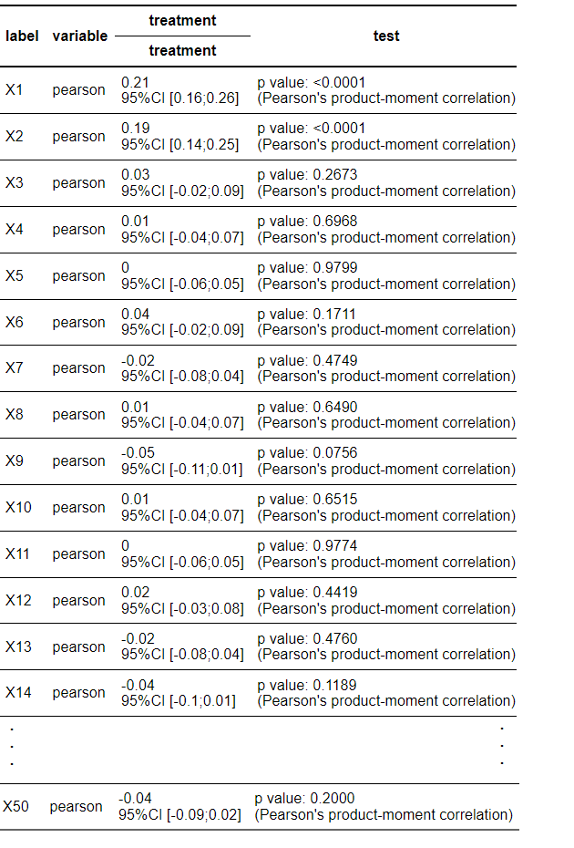

4.) We find that we reject four out of 50 hypothesis tests at the 10% significance level which gives us a rejection rate of 8% (4/50). Similarly, we reject two out of 50 hypothesis tests at the 5% significance level which gives us a rejection rate of 4% (2/50). Both rejection rates are lower than what we would expect under the null hypothesis, 8% is lower than 10% and 4% is lower than 5%.

5.) We start with setting up an empty table with the results that we are going to write in later:

```r
balance_out <- tibble(
  variable = character(),
  mean_treated = numeric(),
  mean_control = numeric(),
  p_value = numeric()
)
```

Now we loop over all covariates and perform a t-test for each variable which is written into a tibble and then appended to the existing balance_out tibble using the command *bind_rows*.

```r
for (i in 1:50) {
  varname <- names(df_balance)[i + 2]
  df_balance$var <- as.vector(df_balance[[i + 2]])

  t_test <- t.test(var ~ treatment, data = df_balance)

  balance_out <- bind_rows(balance_out, tibble(
    variable = varname,
    mean_treated = t_test$estimate[2],  # 2 = treatment == 1
    mean_control = t_test$estimate[1],  # 1 = treatment == 0
    p_value = t_test$p.value
  ))
}
```

Then we look at the variables for which we reject the null hypothesis and calculate the rejection rate as the number of tests for which we reject the null hypothesis divided by the total number of tests conducted (50).

```r
balance_out %>%
  filter(p_value<0.1)
```

```
## # A tibble: 4 × 4
##   variable mean_treated mean_control  p_value
##   <chr>           <dbl>        <dbl>    <dbl>
## 1 X1             0.464       0.00787 3.39e-14
## 2 X2             0.404      -0.00959 5.24e-12
## 3 X9            -0.0583      0.0438  7.57e- 2
## 4 X28            0.0545     -0.0501  6.22e- 2
```

```r
balance_out %>%
  filter(p_value<0.05)
```

```
## # A tibble: 2 × 4
##   variable mean_treated mean_control  p_value
##   <chr>           <dbl>        <dbl>    <dbl>
## 1 X1              0.464      0.00787 3.39e-14
## 2 X2              0.404     -0.00959 5.24e-12
```

```r
length(balance_out$p_value[balance_out$p_value<0.1])/length(balance_out$p_value)
```

```
## [1] 0.08
```

```r
length(balance_out$p_value[balance_out$p_value<0.05])/length(balance_out$p_value)
```

```
## [1] 0.04
```

# Exercise 7.1: Flu shot experiment

1.) Let us denote $\tau$ as the effect of the information campaign on flu vaccination. The null hypothesis is that the campaign has no effect $H_0: \tau =0$, and the alternative hypothesis is that it has an effect $H_A: \tau\neq 0$.

2.) The results table is divided into two different samples in the rows. Those with no flu shot in the previous year have a 2.4 percentage-point higher likelihood to get the flu vaccination if they received the letter. Those with a flu shot in the previous year are 2.3 percentage points more likely to get the vaccination if they received the letter. Relative to the mean of vaccinated in the control group, the effect is much larger for those with no flu shot in the previous year (34.2%) compare to those with a flu shot in the previous year (3.4%). The reason is that the baseline vaccination rate in the season 2016/17 is a lot higher among those individuals who were vaccinated already in 2015/16 than for those who were not vaccinated in 2015/16.

3.) Statistical significance can be assessed by looking at the stars after the point estimates. The coefficient for those with no flu shot in the previous year is followed by three stars. This means that the effect is significant at the 1% significance level. The coefficient for those who took a flu shot in the previous year is followed by one star. This means that the effect is significant at the 10% significance level. The correspondence between stars and significance levels is reported after the bottom horizontal line. The number in parenthesis are standard errors as described in the note of the table.

4.) If the customers of the insurance company were a specific subset of the population of Switzerland, this would pose a problem for external validity. In that case, we could not make valid inferences from the sample of the insurance company’s customers about the full population of the population of Switzerland.

# Exercise 7.2: Working from home

1.) We first read in the data and use the distinct function of the *dplyr* package to look at the different values of *attrite_perc* which are 0 and 100.

```
## # A tibble: 2 × 1
##   attrite_perc
##          <dbl>
## 1            0
## 2          100
```

```r
df_out <- df_home %>%
  group_by(treat) %>%
  summarize(attrition_mean=mean(attrite_perc))
print(df_out)
```

```
## # A tibble: 2 × 2
##   treat attrition_mean
##   <dbl>          <dbl>
## 1     0           7.20
## 2     1           4.80
```

3.) We get the same results when using a regression:

```r
summary(lm(attrite_perc~treat,data=df_home))
```

```
##
## Call:
## lm(formula = attrite_perc ~ treat, data = df_home)
##
## Residuals:
##    Min     1Q Median     3Q    Max
## -7.195 -7.195 -4.798 -4.798 95.202
##
## Coefficients:
##             Estimate Std. Error t value            Pr(>|t|)
## (Intercept)   7.1951     0.8299   8.670 <0.0000000000000002 ***
## treat        -2.3971     1.1840  -2.025              0.0431 *
## ---
## Signif. codes:  0 '***' 0.001 '**' 0.01 '*' 0.05 '.' 0.1 ' ' 1
##
## Residual standard error: 23.77 on 1610 degrees of freedom
## Multiple R-squared:  0.002539,   Adjusted R-squared:  0.00192
## F-statistic: 4.099 on 1 and 1610 DF,  p-value: 0.04307
```

4.) When performing the regression for managers and non-managers separately, we find that only non-managers react to the treatment:

```r
summary(lm(attrite_perc~treat,data=df_home %>% filter(role==1)))
```

```
##
## Call:
## lm(formula = attrite_perc ~ treat, data = df_home %>% filter(role ==
##     1))
##
## Residuals:
##    Min     1Q Median     3Q    Max
## -3.125 -3.125 -2.956 -2.956 97.044
##
## Coefficients:
##             Estimate Std. Error t value Pr(>|t|)
## (Intercept)   2.9557     1.2077   2.447   0.0148 *
## treat         0.1693     1.7322   0.098   0.9222
## ---
## Signif. codes:  0 '***' 0.001 '**' 0.01 '*' 0.05 '.' 0.1 ' ' 1
##
## Residual standard error: 17.21 on 393 degrees of freedom
## Multiple R-squared:  2.432e-05,  Adjusted R-squared:  -0.00252
## F-statistic: 0.009557 on 1 and 393 DF,  p-value: 0.9222
```

```r
summary(lm(attrite_perc~treat,data=df_home %>% filter(role==0)))
```

```
##
## Call:
## lm(formula = attrite_perc ~ treat, data = df_home %>% filter(role ==
##     0))
##
## Residuals:
##    Min     1Q Median     3Q    Max
## -8.590 -8.590 -5.333 -5.333 94.667
##
## Coefficients:
##             Estimate Std. Error t value            Pr(>|t|)
## (Intercept)    8.590      1.025   8.382 <0.0000000000000002 ***
## treat         -3.257      1.460  -2.231              0.0259 *
## ---
## Signif. codes:  0 '***' 0.001 '**' 0.01 '*' 0.05 '.' 0.1 ' ' 1
##
## Residual standard error: 25.46 on 1215 degrees of freedom
## Multiple R-squared:  0.00408,    Adjusted R-squared:  0.003261
## F-statistic: 4.978 on 1 and 1215 DF,  p-value: 0.02585
```

5.) The point estimates and p-values are identical.

6.) It seems that only women react, men do not. In addition, only those with a longer commute react to the treatment, even though the point estimates are not too different (-2.6 vs. -3.1). But the point estimates are only significantly different from zero for individuals with a longer commute because working from home makes a difference for them.

Additional: We can create a similar graph as in the paper with the following code:

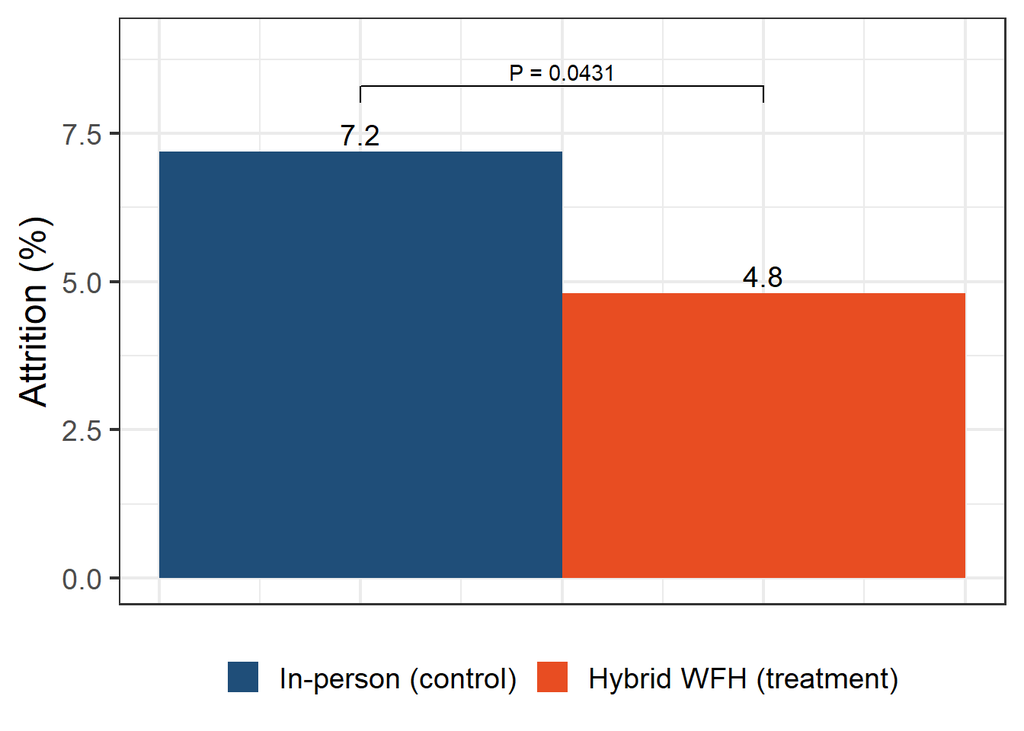

```r
library(ggsignif)
ggplot(df_out, aes(x=treat, y=attrition_mean,fill=factor(treat),
                   label=round(attrition_mean,1))) +
  geom_col(width = 1) +
  geom_text(aes(y=attrition_mean+0.3),size=5) +
  geom_signif(y_position = c(8.3), xmin = c(0.0), xmax = c(1.0),
    annotation = c("P = 0.0431"), tip_length = 0.1) +
  scale_fill_manual(values = c("#1f4e79", "#e84d22"),
                    breaks=c(0,1),
                    label=c("In-person (control)",
                            "Hybrid WFH (treatment)"))   +
  scale_y_continuous(limits = c(0,9)) +
  theme_bw(base_size=18) +
  theme(axis.title.x = element_blank(),
        axis.text.x = element_blank(), axis.ticks.x = element_blank()) +
  ylab("Attrition (%)")  +
  theme(legend.position = "bottom",
        legend.title = element_blank())
```

# Exercise 8.1: Teaching methods

1.) The null hypothesis is that all means are equal, $H_0 : \mu_1 = \mu_2 = \mu_3 =\mu_4 = \mu_5$. The alternative hypothesis $H_A$ is that at least two of the means $\mu_i$ are different.

2.) We have 45 students in five groups. Thus the degrees of freedom in the numerator are 5-1=4 (k-1) and those in the denominator are 45-5 (n-k).

3.) It seems that the score for those in the “Lecture”, “Text+Lecture”, and in the “Computer+Lecture” treatments are higher than the others.

4.) This impression is confirmed by the ANOVA results according to which we reject our null hypothesis with a p-value of 0.000282. The degrees of freedom can be deduced in the column Df. The MSG is 24.339 and MSE is 3.576, leading to an F-value of 6.805.

# Exercise 8.2: Pain relief

We first read in the results:

1.) The distribution of the pain measure across groups looks as follows:

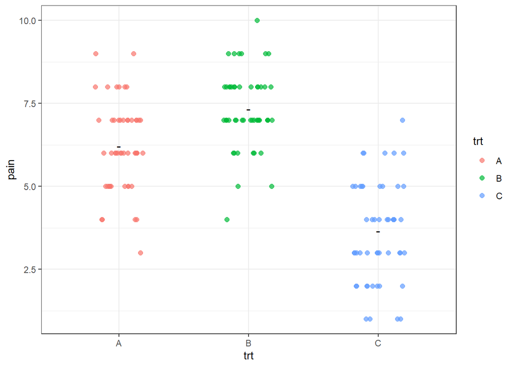

```r
ggplot(painstudy, aes(x = trt, y = pain, color = trt)) +
  geom_jitter(width = 0.2, height=0, size = 2, alpha = 0.7) +
  stat_summary(fun = mean, geom = "point",
               shape = "-", size = 4, color = "black") +
  theme_bw()
```

It seems that group C had a lower pain level than the other two groups.

2.) This visual impression is confirmed when taking the averages across groups. While the mean pain level in group C is 3.64, it is 6.2 in group A and 7.32 in group B.

```r
painstudy %>%
  group_by(trt) %>%
  summarize(pain_mean=mean(pain))
```

```
## # A tibble: 3 × 2
##   trt   pain_mean
##   <chr>     <dbl>
## 1 A          6.2
## 2 B          7.32
## 3 C          3.64
```

3.) The null hypothesis is that all means are equal, $H_0 : \mu_1 = \mu_2 = \mu_3$. The alternative hypothesis $H_A$ is that at least two of the means are different.

4.) We implement ANOVA using the command *aov*. Because the p-value is clearly under 0.05, we reject the null hypothesis at the 5% significance level.

```r
anova_mod <- aov(pain ~ trt, data = painstudy)
summary(anova_mod)
```

```
##              Df Sum Sq Mean Sq F value              Pr(>F)
## trt           2  355.8   177.9   98.92 <0.0000000000000002 ***
## Residuals   147  264.4     1.8
## ---
## Signif. codes:  0 '***' 0.001 '**' 0.01 '*' 0.05 '.' 0.1 ' ' 1
```

5.) The adjusted $\alpha^*=\frac{\alpha}{k(k-1)/2}=0.01666$ as k=3. The p-values of the following tests are all smaller than 0.0166 and thus we reject the null hypothesis that the means are equal for all three comparisons.

```r
t.test(pain~trt,data=painstudy %>% filter(trt %in% c("A","B")))
```

```
##
##  Welch Two Sample t-test
##
## data:  pain by trt
## t = -4.4836, df = 95.809, p-value = 0.00002036
## alternative hypothesis: true difference in means between group A and group B is not equal to 0
## 95 percent confidence interval:
##  -1.6158616 -0.6241384
## sample estimates:
## mean in group A mean in group B
##            6.20            7.32
```

```r
t.test(pain~trt,data=painstudy %>% filter(trt %in% c("A","C")))
```

```
##
##  Welch Two Sample t-test
##
## data:  pain by trt
## t = 8.9708, df = 96.657, p-value = 0.00000000000002296
## alternative hypothesis: true difference in means between group A and group C is not equal to 0
## 95 percent confidence interval:
##  1.993592 3.126408
## sample estimates:
## mean in group A mean in group C
##            6.20            3.64
```

```r
t.test(pain~trt,data=painstudy %>% filter(trt %in% c("B","C")))
```

```
##
##  Welch Two Sample t-test
##
## data:  pain by trt
## t = 13.715, df = 91.597, p-value < 0.00000000000000022
## alternative hypothesis: true difference in means between group B and group C is not equal to 0
## 95 percent confidence interval:
##  3.147046 4.212954
## sample estimates:
## mean in group B mean in group C
##            7.32            3.64
```

# Exercise 9.1: Weight loss

We first read in the data:

1.) The mean effects can be calculated as follows:

```r
mean(wtlossdat["y"][wtlossdat["A"] == 1]) -
  mean(wtlossdat["y"][wtlossdat["A"] == -1])
```

```
## [1] 0.4554145
```

```r
mean(wtlossdat["y"][wtlossdat["B"] == 1]) -
  mean(wtlossdat["y"][wtlossdat["B"] == -1])
```

```
## [1] -1.892005
```

```r
mean(wtlossdat["y"][wtlossdat["C"] == 1]) -
  mean(wtlossdat["y"][wtlossdat["C"] == -1])
```

```
## [1] 0.5768074
```

It seems that treatment B was most effective in reducing weight, while weight increased for the other two conditions.

2.) The regression can be calculated with a model with interaction terms:

```r
mod <- lm(y ~ factor(A) * factor(B)  * factor(C), data = wtlossdat)
summary(mod)
```

```
##
## Call:
## lm(formula = y ~ factor(A) * factor(B) * factor(C), data = wtlossdat)
##
## Residuals:
##     Min      1Q  Median      3Q     Max
## -3.3880 -0.6415 -0.0145  0.6127  3.2177
##
## Coefficients:
##                                  Estimate Std. Error t value             Pr(>|t|)
## (Intercept)                       0.94324    0.10015   9.418 < 0.0000000000000002 ***
## factor(A)1                        0.03498    0.14163   0.247              0.80501
## factor(B)1                       -1.08863    0.14163  -7.686   0.0000000000000448 ***
## factor(C)1                        0.89800    0.14163   6.340   0.0000000003847915 ***
## factor(A)1:factor(B)1            -0.37744    0.20030  -1.884              0.05988 .
## factor(A)1:factor(C)1             0.58690    0.20030   2.930              0.00349 **
## factor(B)1:factor(C)1            -1.86071    0.20030  -9.290 < 0.0000000000000002 ***
## factor(A)1:factor(B)1:factor(C)1  1.26283    0.28327   4.458   0.0000094622165495 ***
## ---
## Signif. codes:  0 '***' 0.001 '**' 0.01 '*' 0.05 '.' 0.1 ' ' 1
##
## Residual standard error: 1.001 on 792 degrees of freedom
## Multiple R-squared:  0.5565, Adjusted R-squared:  0.5526
## F-statistic:   142 on 7 and 792 DF,  p-value: < 0.00000000000000022
```

# Exercise 9.2: Flu vaccination

We first read in the data:

1.) The effect for the incentive treatment is 0.94-0.571=0.369. This means that those with the incentive treatment are 36.9 percentage points more likely to get vaccinated than those with no incentive treatment.

```r
df_vaccination %>%
  group_by(D_incentive) %>%
  summarize(Vaccinated_mean=mean(Vaccinated))
```

```
## # A tibble: 2 × 2
##   D_incentive Vaccinated_mean
##         <dbl>           <dbl>
## 1           0           0.571
## 2           1           0.940
```

The effect for the reminder treatment is 0.810-0.700=0.11. This means that those with the reminder treatment are 11 percentage points more likely to get vaccinated.

```r
df_vaccination %>%
  group_by(D_reminder) %>%
  summarize(Vaccinated_mean=mean(Vaccinated))
```

```
## # A tibble: 2 × 2
##   D_reminder Vaccinated_mean
##        <dbl>           <dbl>
## 1          0           0.700
## 2          1           0.810
```

2.) The regression looks as follows

```r
summary(lm(Vaccinated ~ D_incentive*D_reminder, data=df_vaccination))
```

```
##
## Call:
## lm(formula = Vaccinated ~ D_incentive * D_reminder, data = df_vaccination)
##
## Residuals:
##     Min      1Q  Median      3Q     Max
## -0.8821  0.0000  0.1179  0.3726  0.4882
##
## Coefficients:
##                        Estimate Std. Error t value             Pr(>|t|)
## (Intercept)            0.511811   0.024127  21.213 < 0.0000000000000002 ***
## D_incentive            0.370318   0.033828  10.947 < 0.0000000000000002 ***
## D_reminder             0.115565   0.033828   3.416              0.00066 ***
## D_incentive:D_reminder 0.002305   0.047840   0.048              0.96158
## ---
## Signif. codes:  0 '***' 0.001 '**' 0.01 '*' 0.05 '.' 0.1 ' ' 1
##
## Residual standard error: 0.3845 on 1030 degrees of freedom
## Multiple R-squared:  0.2031, Adjusted R-squared:  0.2007
## F-statistic: 87.48 on 3 and 1030 DF,  p-value: < 0.00000000000000022
```

3.) The coefficients are the means in the different groups. The baseline vaccination probability is 51.1 percent. The incentive treatment increases this probability by 37 percentage points to 88.1 percent, while the reminder treatment increases it by 11.6 percentage points to 62.7 percent.

4.) The interaction effect of both treatments is very close to zero and not statistically different from zero with a p-value of 0.96.

5.) The interaction plot looks as follows:

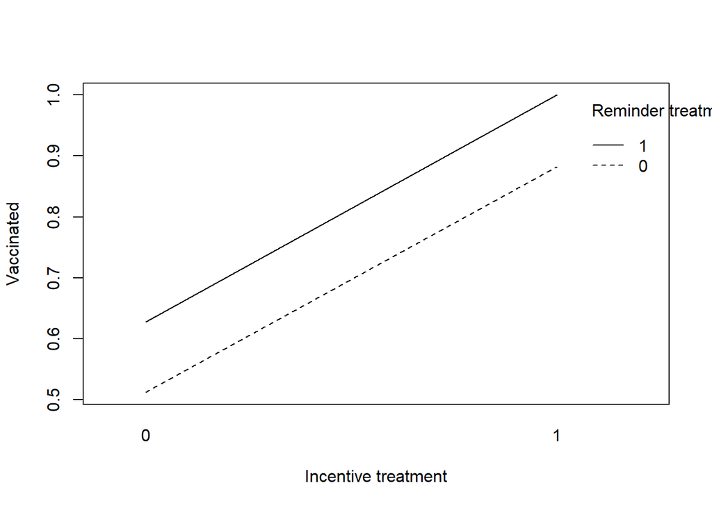

```r
interaction.plot(x.factor=df_vaccination$D_incentive,
                 trace.factor=df_vaccination$D_reminder,
                 response=df_vaccination$Vaccinated, type="l",
                 xlab="Incentive treatment",trace.label="Reminder treatment",
                 ylab="Vaccinated")
```

6.) The interpretation of the interaction plot is that the shift in the lines (dashed to solid) is the impact of the reminder treatment, while the increase from 0 to 1 on the a-axis is the impact of the incentive treatment. It is notable that the incentive effect is substantially larger than the reminder effect. The interaction effect would be the difference at x=1 (solid minus dashed) minus the difference at x=0 (solid minus dashed). But since the lines are almost parallel, the interaction effect is close to zero.

# Exercise 10.1: Vacuum cleaner

1.) The attributes are color, name, and price.

2.) The attribute levels are blue vs. red for color, Top Cleaner vs. CleanR for name, and 1000 vs. 800 Swiss Francs for price.

3.) The “Stability and No Carryover Effects” means that individuals will always take the same decision when confronted with two scenarios independent of when this choice task is presented (first or last for a respondent). The “No Profile-Order Effects” means that people decide only based on the attribute levels and not where on the screen the profiles are presented. The “Randomization of the Profiles” means that the attribute levels are randomized.

4.) It seems that the name “CleanR” has the largest positive effect on people’s purchase decision. Those presented with a vacuum cleaner with the name “CleanR” are over 40 percentage points more likely to buy the product than those with a vacuum cleaner with the name “Top Cleaner”. The color red and the lower price of 800 also have positive effects of slightly below 20 percentage points for red and slightly above 20 percentage points for the price of 800.

# Exercise 10.2: Immigrant admission

We load the Rdata using the *load* command:

1.) The distribution of language skills and gender is as follows:

```r
library(janitor)
df_immigration %>%
  tabyl(`Language Skills`,Gender) %>%
  adorn_percentages("all")%>%
  adorn_pct_formatting(digits = 1)
```

```
##           Language Skills female  male
##            fluent English  12.9% 12.8%
##            broken English  12.5% 12.2%
##  tried English but unable  13.0% 12.0%
##          used interpreter  12.7% 11.9%
```

This resembles very much a random distribution across those two attributes because the shares in each cell are what we would expect under perfect randomization (100%/8 cells=12.5%).

2.) When looking at distribution between *Education* and *Job*, we get the following results:

```r
df_immigration %>%
  tabyl(Education,Job) %>%
  adorn_percentages("all")%>%
  adorn_pct_formatting(digits = 1)
```

```
##         Education janitor waiter child care provider gardener financial analyst construction worker teacher computer programmer nurse research scientist
##         no formal    2.1%   2.0%                2.1%     1.8%              0.0%                2.0%    2.0%                0.0%  2.1%               0.0%
##         4th grade    1.9%   2.0%                2.3%     2.0%              0.0%                2.0%    2.1%                0.0%  2.1%               0.0%
##         8th grade    2.1%   2.2%                2.0%     2.0%              0.0%                1.8%    2.0%                0.0%  2.1%               0.0%
##       high school    1.7%   2.0%                2.3%     2.0%              0.0%                2.1%    2.1%                0.0%  2.1%               0.0%
##  two-year college    1.3%   1.2%                1.4%     1.2%              1.2%                1.3%    1.4%                1.2%  1.4%               1.3%
##    college degree    1.4%   1.4%                1.2%     1.4%              1.1%                1.3%    1.2%                1.4%  1.3%               1.2%
##   graduate degree    1.2%   1.5%                1.2%     1.4%              1.2%                1.4%    1.3%                1.3%  1.2%               1.4%
##  doctor
##    0.0%
##    0.0%
##    0.0%
##    0.0%
##    1.3%
##    1.2%
##    1.5%
```

It appears that the authors created that design such that very high-level occupations, such as financial analyst, computer programmer, research scientist, and doctor, are not combined with very low levels of education. This is a sensible choice since we rarely observe these combinations in reality.

3.) The full model can be estimated using the *amce* command from the *cjoint* library:

```r
library(cjoint)
```

We can also replace the dark gray background with a classical white background using the argument *plot.theme* in the command *plot*.

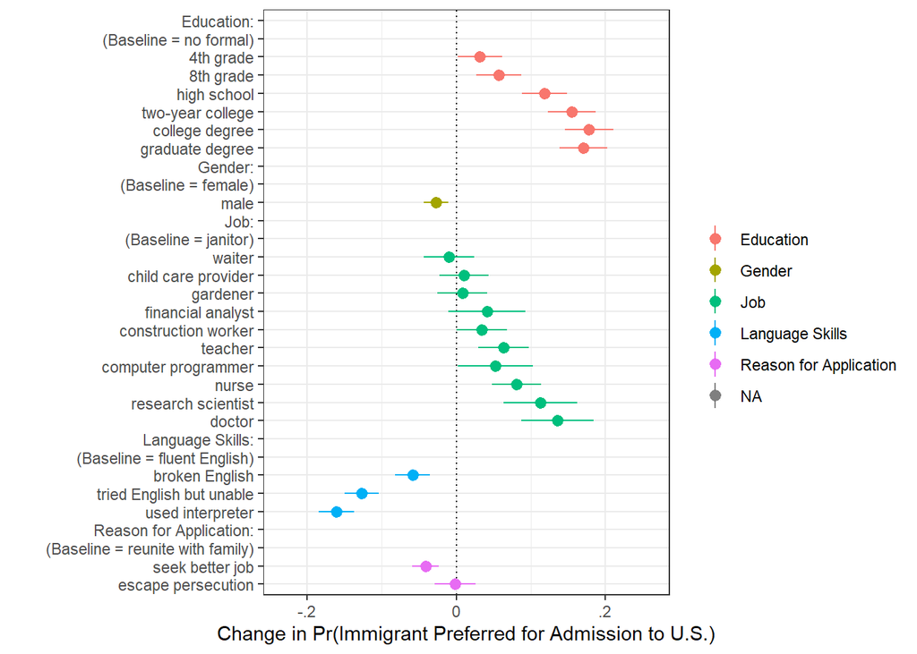

```r
results <- amce(Chosen_Immigrant ~  Gender + Education + `Language Skills` +
                    +  Job +`Reason for Application` ,
                data=df_immigration,
                cluster=TRUE,
                respondent.id="CaseID")

plot(results ,
     xlab="Change in Pr(Immigrant Preferred for Admission to U.S.)",
     ylim=c(-.3,.3),
     breaks=c(-.2, 0, .2),
     labels=c("-.2","0",".2"), text.size=13,
     plot.theme = theme_bw())
```

# Exercise 11.1: Income and job performance

1.) Cohen’s D is 20/100=0.2.

```r
library(pwrss)

power.t.student(d = 0.2,
                power = 0.80,
                alpha = 0.05,
                alternative = "two.sided",
                design = "independent")
```

```
## +--------------------------------------------------+
## |             SAMPLE SIZE CALCULATION              |
## +--------------------------------------------------+
##
## Student's T-Test (Independent Samples)
##
## ---------------------------------------------------
## Hypotheses
## ---------------------------------------------------
##   H0 (Null Claim) : d - null.d = 0
##   H1 (Alt. Claim) : d - null.d != 0
##
## ---------------------------------------------------
## Results
## ---------------------------------------------------
##   Sample Size            = 394 and 394  <<
##   Type 1 Error (alpha)   = 0.050
##   Type 2 Error (beta)    = 0.199
##   Statistical Power      = 0.801
```

3.) When repeating the exercise for a higher level of power, we observe that the sample size demanded increases to 1054 and 1302 individuals:

```r
power.t.student(d = 0.2,
                power = 0.9,
                alpha = 0.05,
                alternative = "two.sided",
                design = "independent")
```

```
## +--------------------------------------------------+
## |             SAMPLE SIZE CALCULATION              |
## +--------------------------------------------------+
##
## Student's T-Test (Independent Samples)
##
## ---------------------------------------------------
## Hypotheses
## ---------------------------------------------------
##   H0 (Null Claim) : d - null.d = 0
##   H1 (Alt. Claim) : d - null.d != 0
##
## ---------------------------------------------------
## Results
## ---------------------------------------------------
##   Sample Size            = 527 and 527  <<
##   Type 1 Error (alpha)   = 0.050
##   Type 2 Error (beta)    = 0.100
##   Statistical Power      = 0.9
```

```r
power.t.student(d = 0.2,
                power = 0.95,
                alpha = 0.05,
                alternative = "two.sided",
                design = "independent")
```

```
## +--------------------------------------------------+
## |             SAMPLE SIZE CALCULATION              |
## +--------------------------------------------------+
##
## Student's T-Test (Independent Samples)
##
## ---------------------------------------------------
## Hypotheses
## ---------------------------------------------------
##   H0 (Null Claim) : d - null.d = 0
##   H1 (Alt. Claim) : d - null.d != 0
##
## ---------------------------------------------------
## Results
## ---------------------------------------------------
##   Sample Size            = 651 and 651  <<
##   Type 1 Error (alpha)   = 0.050
##   Type 2 Error (beta)    = 0.050
##   Statistical Power      = 0.95
```

```r
power.t.student(d = 0.2,
                power = 0.8,
                alpha = 0.01,
                alternative = "two.sided",
                design = "independent")
```

```
## +--------------------------------------------------+
## |             SAMPLE SIZE CALCULATION              |
## +--------------------------------------------------+
##
## Student's T-Test (Independent Samples)
##
## ---------------------------------------------------
## Hypotheses
## ---------------------------------------------------
##   H0 (Null Claim) : d - null.d = 0
##   H1 (Alt. Claim) : d - null.d != 0
##
## ---------------------------------------------------
## Results
## ---------------------------------------------------
##   Sample Size            = 586 and 586  <<
##   Type 1 Error (alpha)   = 0.010
##   Type 2 Error (beta)    = 0.200
##   Statistical Power      = 0.8
```

5.) The analysis suggests that the treatment effect is 17.7 which is not far from the 20 that we suspected.

```r
df_experimental <- read_csv("../Data/Out_Data/lecture11_income_performance.csv")
summary(lm(Y~D,data=df_experimental))
```

```
##
## Call:
## lm(formula = Y ~ D, data = df_experimental)
##
## Residuals:
##     Min      1Q  Median      3Q     Max
## -164.24  -94.24   -1.90   88.10  168.10
##
## Coefficients:
##             Estimate Std. Error t value            Pr(>|t|)
## (Intercept)  834.240      6.289 132.656 <0.0000000000000002 ***
## D             17.660      8.894   1.986              0.0476 *
## ---
## Signif. codes:  0 '***' 0.001 '**' 0.01 '*' 0.05 '.' 0.1 ' ' 1
##
## Residual standard error: 99.43 on 498 degrees of freedom
## Multiple R-squared:  0.007855,   Adjusted R-squared:  0.005863
## F-statistic: 3.943 on 1 and 498 DF,  p-value: 0.04762
```

# Exercise 11.2: Ratings and revenues

1.) We can generate a random Bernoulli assignment using the *simple_ra* command from the *randomizr* package:

```r
library(randomizr)
set.seed(1234)
simple_ra(N = 8, prob=0.5)
```

```
## [1] 0 1 1 1 1 1 0 0
```

We observe that five restaurants are assigned to treatment, while three are assigned to control.

2.) We get four treated and four control restaurants using the completely randomized design which we can generate using the *complete_ra* command from the *randomizr* package:

```r
library(randomizr)
complete_ra(N = 8, prob=0.5)
```

```
## [1] 1 0 0 1 1 0 1 0
```

3.) We read in the data and then use the *strata_rs* command from the *randomizr* package to get a stratified randomization which is a complete randomization scheme for each level of the strata variable:

```r
df_randomization <- read_csv("../Data/Out_Data/lecture11_ratings_revenues.csv")
strata_rs(strata = df_randomization$High_Quality)
```

```
## [1] 0 1 1 0 0 1 1 0
```

4.) The advantage is that the strata variables are balanced by construction. In larger samples, balance is less of a problem because the law of large numbers will make covariates balanced. In small samples, however, we can get unlucky with the randomization and may have an imbalance in certain covariates.